# Final Project PSTAT 131

Richard Antony

2022-10-03

## Introduction

In this project, I will be first doing Exploratory Data Analysis. I will look through the spread of the response and how its distributed. Then I will see how each variables correlate with one another. After doing EDA, I then will proceed to split and cross validate the data. After splitting and cross validation is done, I will then build 3 models (Logistic Regression, Tree Classifciation Model & Boosted Tree Models). Each model will have parameters that are tune to achive the best model. The metric I use for validating it to be the best model is by looking at the ROC_AUC.

### Loading Packages

```r
library(ggplot2)
library(tidyverse)
library(dplyr)
library(tidyverse)
#install.packages('tidymodels')
library(tidymodels)
#install.packages('ISLR')
library(ISLR)
library(kernlab)
library(tidyverse)
library(tidymodels)
library(ISLR)
#install.packages('rpart.plot')
library(rpart.plot)
#install.packages('vip')
library(vip)
library(janitor)
library(randomForest)
library(xgboost)
library(tidymodels)
library(ISLR)
library(tidyverse)
library(tidymodels)
library(ISLR)
library(ISLR2)
library(tidyverse)
library(glmnet)
tidymodels_prefer()
library(tidymodels)
library(ISLR)
library(ISLR2)
library(tidyverse)
library(tidymodels)
library(ISLR) # For the Smarket data set
library(ISLR2) # For the Bikeshare data set
library(discrim)
library(poissonreg)
library(corrr)
library(klaR) # for naive bayes
#install.packages('corrplot')
library(corrplot)
```

## EDA

```r
#Read Data

data<-read.csv('~/Desktop/PSTAT 131 /Final Project/Data/credit_risk_dataset.csv')

# Omit values because only takes up 12% of the data which is not alot.
#32581 -28638
#3943/32581
data <-data %>% na.omit()
data<-data %>%  clean_names()

#Make variables to be factor if needed
data$person_home_ownership<-as.factor(data$person_home_ownership)
data$loan_intent<-as.factor(data$loan_intent)
data$loan_grade<-as.factor(data$loan_grade)
data$loan_status<-as.factor(data$loan_status)
data$cb_person_default_on_file<-as.factor(data$cb_person_default_on_file)

#Make double & integer variable into numeric
data$loan_int_rate <-as.numeric(data$loan_int_rate)
data$loan_percent_income<- as.numeric(data$loan_percent_income)
data$person_age<-as.numeric(data$person_age)
data$person_income<-as.numeric(data$person_income)
data$loan_amnt<-as.numeric(data$loan_amnt)
data$cb_person_cred_hist_length<-as.numeric(data$cb_person_cred_hist_length)
```

### Check spread of outcome variable

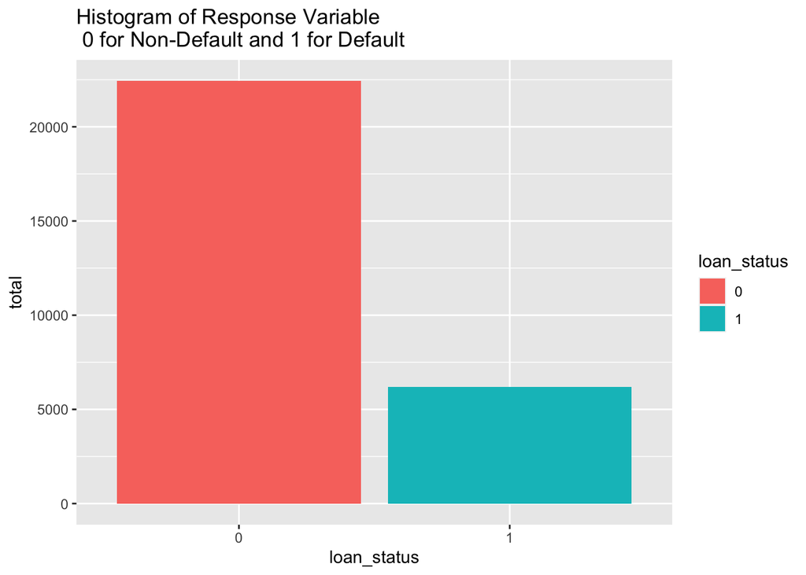

```r
Outcome_spread<-data %>% select(loan_status) %>% group_by(loan_status) %>% summarise(total=sum(n()))

ggplot(Outcome_spread,aes(loan_status,total,fill=loan_status)) + geom_col() + ggtitle("Histogram of Response Variable\n 0 for Non-Default and 1 for Default")
```

We see that in the histogram of the outcome variable most of it is spread in 0 rather than 1. The outcome data is imbalance. We see that loan_status that is ‘0’ is 22435 while loan_status that is ‘1’ is 6203. This means that 78% the outcome observations are ‘0’ while 22% of the outcome observations are 22% of the total data. Most of my observations is non default and only few is default. But we need to explore the data further.

### Check correlation between variables

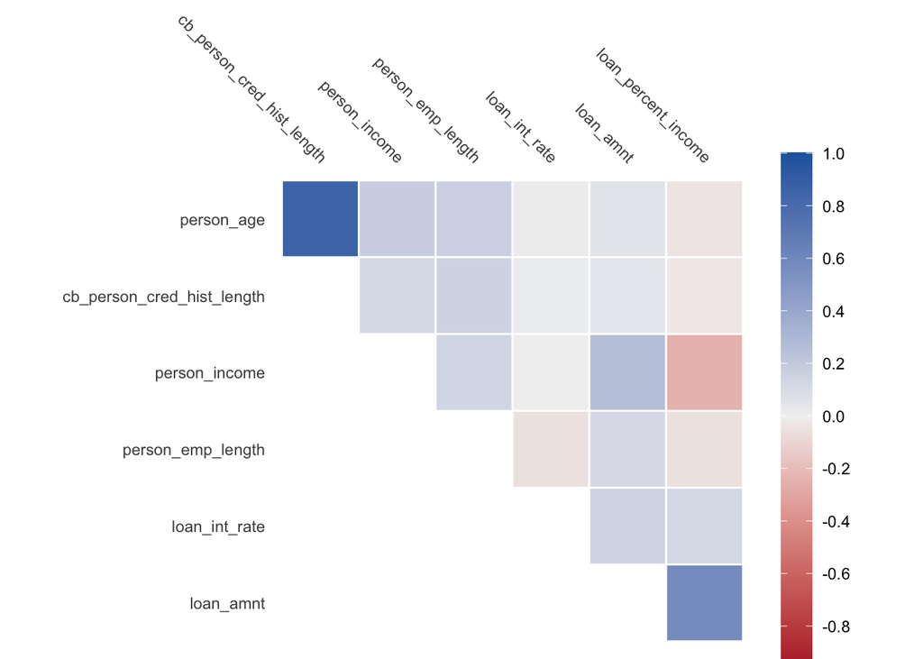

```r
corr_data<-correlate(data)

corr_data %>% autoplot(type="heatmap")
```

From the correlation plot with heatmap we see that some variables are highly correlated to one another. Example of this can be the variable “person_age” with “cb_person_cred_hist_length” which have a correlation between 0.8 to 1. But looking through it I dont think this has to be removed. “cb_person_cred_hist_length” is the credit history length and “person_age” is just age. Its not like the variable “cb_person_cred_hist_length” value is derived from “person_age” like the question from the homework. So I will still keep all the varaible.

### Check relations between loan_status to loan_amount with boxplot

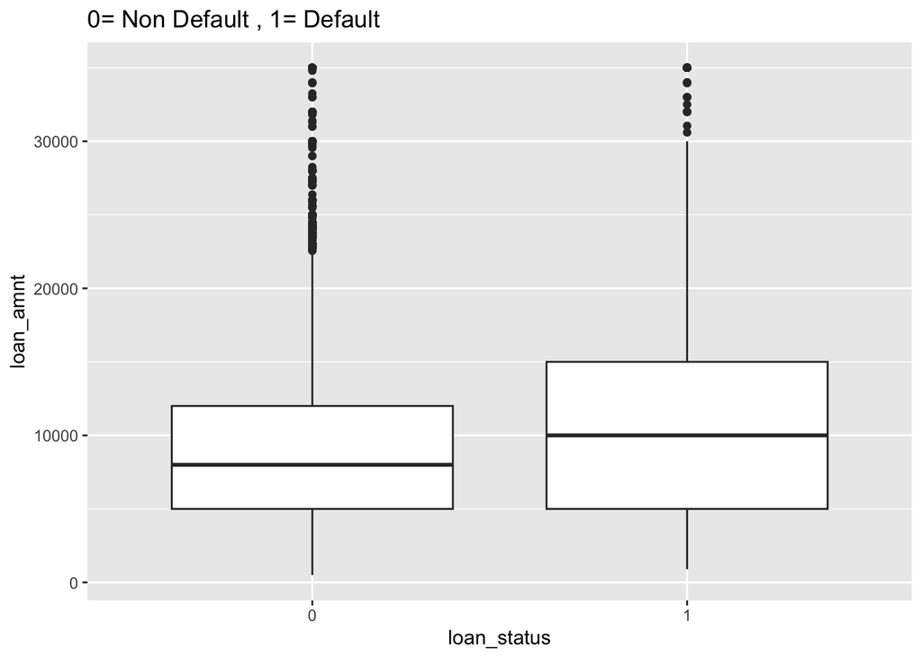

```r
ggplot(data,aes(loan_status,loan_amnt)) + geom_boxplot() +ggtitle("0= Non Default , 1= Default")
```

‘0’ for non default . ‘1’ for default. Now in this box plot I try to see the relationship between loan amount (loan_amnt) and loan status. I see that the higher the loan amount is, the higher people would likely to default. We can observe that the median for people who defaulted (1) has a higher median than those people who dont (0). Lets explore further.

## Data Splitting & Cross Validation Folding

```r
set.seed(9898)
# 80 % to train 20% to test
data_split<-initial_split(data,prop = 0.8,strata = loan_status)
data_train <-training(data_split)
data_test<- testing(data_split)
```

### Data folding

```r
set.seed(9898)
data_train_fold <- vfold_cv(data_train, v = 10, strata = loan_status)
```

### Receipe

```r
data_rec<-recipe(loan_status~person_age+ person_income+ person_home_ownership+ person_emp_length+ loan_intent+ loan_grade+ loan_amnt+ loan_int_rate+ loan_percent_income+ cb_person_default_on_file + cb_person_cred_hist_length,data = data_train) %>% step_dummy(all_nominal_predictors()) %>% step_normalize(all_predictors())
```

In this section, I split my data to 80% train and 20% test. This is due to the fact that the more % of the data for the train, the more observations that can be studied and thus have a higher chance to create better result for the testing data. I split it base on stratification of the target variable (loan_status). After the split was done, I then apply folding to the train data base on stratifying the target variable (loan_status) 10 times. This is to make sure that each fold will have adequate categories( 0= Non Default and 1= Default). If cross validation is not done on the folds, then some folds can have the response variable imbalnce, meaning might have more 1’s or 0’s in the fold. Cross validation is also useful here because as we see our response variable are quite imbalance. Having Most of the response to 0 (Non Default) and less to 1 (Default). Cross validation ensures that the folds have a good amount of the 2 type of responses to be studied in the training set.

After folding and splitting, I then create a recipe for the training data. This recipe will be use heavily as it can be fit to any models depending on the set_engine and workflow.

## Model Creation

### Logistic Regression

In this part, I tried to fit the data using logistic regression model and tune it with the parameters mixture and penalty. The penalties are both use from Lasso and Ridge regression model.

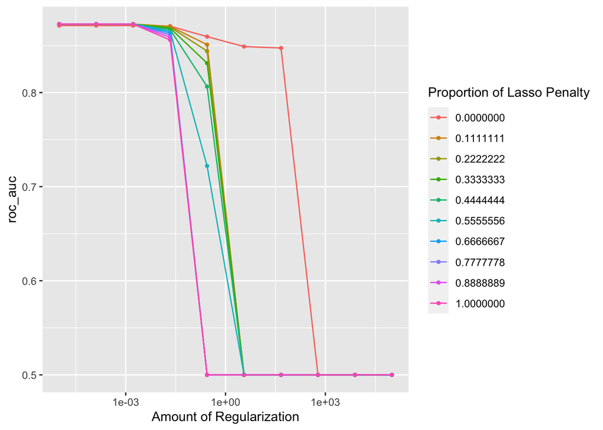

```r
log_reg<-logistic_reg(penalty = tune(), mixture = tune()) %>%  set_engine("glmnet") %>%  set_mode("classification")

tuned_log_wkflow <- workflow() %>%
  add_model(log_reg) %>%
  add_recipe(data_rec)

degree_grid <- grid_regular(penalty(range = c(-5,5)),mixture(range = c(0,1)), levels = 10)

#tune_log_res <- tune_grid(object = tuned_log_wkflow, resamples = data_train_fold, grid = degree_grid, metrics = metric_set(roc_auc), control = control_grid(verbose = T))

#save(tune_log_res,file = "tune_log_res.rda")
load(file="tune_log_res.rda")

autoplot(tune_log_res)
```

```r
require(knitr)
lr_metrics <- collect_metrics(tune_log_res ) %>% dplyr::arrange(desc(mean))

df <- data.frame(Metric = lr_metrics$.metric, Value = lr_metrics $mean, Standard_Error = lr_metrics$std_err, Penalty_Value = lr_metrics$penalty, Mixture_Value = lr_metrics$mixture )

kable(head(df))
```

| Metric | Value | Standard_Error | Penalty_Value | Mixture_Value |
| --- | --- | --- | --- | --- |
| roc_auc | 0.8727775 | 0.0031711 | 0.0016681 | 0.1111111 |
| roc_auc | 0.8727561 | 0.0031856 | 0.0000100 | 0.7777778 |
| roc_auc | 0.8727561 | 0.0031856 | 0.0001292 | 0.7777778 |
| roc_auc | 0.8727533 | 0.0031875 | 0.0000100 | 0.8888889 |
| roc_auc | 0.8727533 | 0.0031875 | 0.0001292 | 0.8888889 |
| roc_auc | 0.8727518 | 0.0031890 | 0.0000100 | 1.0000000 |

```r
best_lr_roc_auc<-df[1,2]
lr_se<-df[1,3]
```

Using Logistic Regresion and tuning the parameter mixture & penalty, I got a model that has the best ROC_AUC of 0.8727775  
with standard error of 0.0031711, Penalty_Value of 0.0016681 and a 0.1111111. I will try other models from here. I will compare their ROC_AUC in which the highest is the best model.

### Simple Tree Model

Having 11 predictors, we have a lot of ways to fit the model for the data. So the parameter we are tuning to find the best model is cost_complexity. This cost complexity parameter will determine the minimun improvement in the model needed in each node.

```r
set.seed(9898)
tree_spec <- decision_tree() %>%
  set_engine('rpart') %>%
  set_mode('classification')

tree_wf <- workflow()%>%
  add_model(tree_spec %>% set_args(cost_complexity = tune())) %>%
  add_formula(loan_status~person_age+ person_income+ person_home_ownership+ person_emp_length+ loan_intent+ loan_grade+ loan_amnt+ loan_int_rate+ loan_percent_income+ cb_person_default_on_file + cb_person_cred_hist_length)


tree_param <- grid_regular(cost_complexity(range = c(-3,-1)), levels = 10)

tune_tree_res <- tune_grid(tree_wf, resamples = data_train_fold, grid = tree_param, metrics = metric_set(roc_auc), control = control_grid(verbose = T))

#save(tune_tree_res,file = "tune_tree_res.rda")
#load(file="tune_tree_res.rda")
```

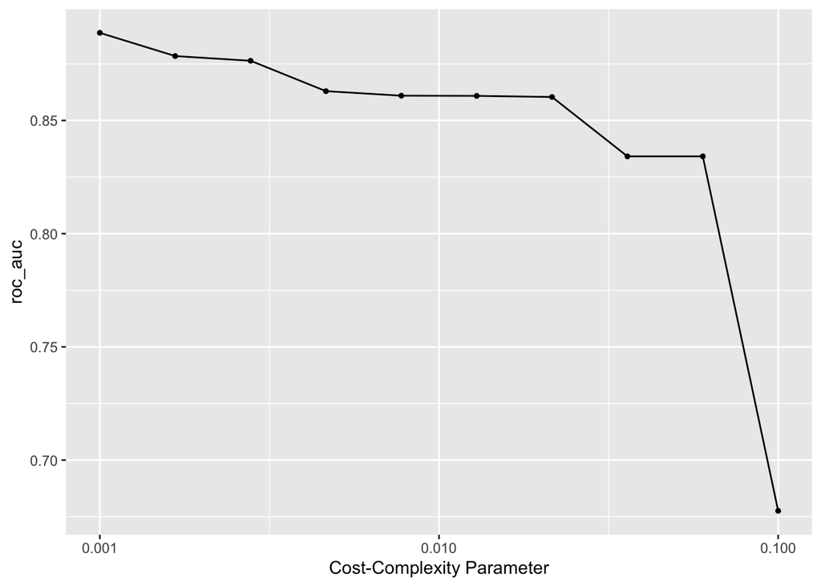

```r
autoplot(tune_tree_res)
```

```r
tree_metrics <- collect_metrics(tune_tree_res) %>% dplyr::arrange(desc(mean))

#Create Table
df <- data.frame(Metric = tree_metrics$.metric, Value = tree_metrics$mean, Standard_Error = tree_metrics$std_err, Cost_Complexity_Value = tree_metrics$cost_complexity )

kable(head(df))
```

| Metric | Value | Standard_Error | Cost_Complexity_Value |
| --- | --- | --- | --- |
| roc_auc | 0.8887092 | 0.0042210 | 0.0010000 |
| roc_auc | 0.8784456 | 0.0034500 | 0.0016681 |
| roc_auc | 0.8763692 | 0.0034215 | 0.0027826 |
| roc_auc | 0.8629446 | 0.0039080 | 0.0046416 |
| roc_auc | 0.8609464 | 0.0039831 | 0.0077426 |
| roc_auc | 0.8608701 | 0.0039485 | 0.0129155 |

```r
best_tree_roc_auc<-df[1,2]
tree_se<-df[1,3]
```

As we can see here, the simple tree model did better than the logistic regression model. We see that the simple tree model has the best roc_auc of 0.8887092 and standard error of 0.0042210 with complexity value of 0.0010000. I think the reason it did better because tree models resample the train data to each nodes and make models out of every node and compare which is the best.

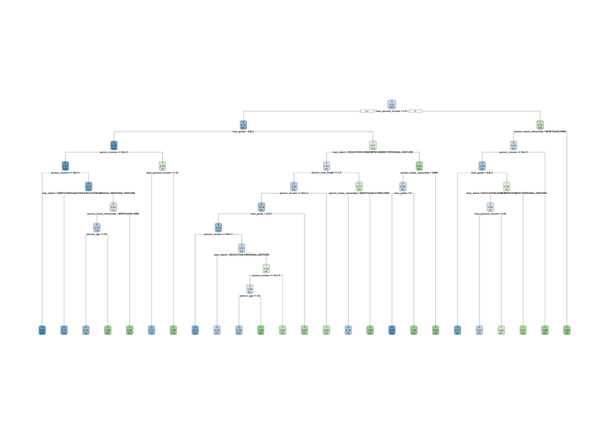

```r
best_tree <- select_best(tune_tree_res, metric = 'roc_auc')

tree_final <- finalize_workflow(tree_wf, best_tree)

tree_final_fit <- fit(tree_final, data = data_train)

tree_final_fit %>%
  extract_fit_engine() %>%
  rpart.plot()
```

Here we can see the nodes that are created by the tree model. The nodes are seleceted and created by the program.

### Boosted Tree Model

In the boosted tree model, our parameters are the trees. We are using the xgboost (Gradient Boosting) for the boosted tree models. My trees range from 10:1000 to make sure every observations is studied thouroghly. The hyperparameters here that we will be tuning is the trees ranging from 10 to 1000 so that every observations is studied thouroughly.

```r
set.seed(9898)

boost_spec <- boost_tree(trees = tune()) %>%
  set_engine('xgboost') %>%
  set_mode('classification')

boost_wf <- workflow() %>%
  add_model(boost_spec) %>%
  add_recipe(data_rec)


boost_param <- grid_regular(trees(range = c(10,1000)), levels = 10)

tune_boost_res <- tune_grid(boost_wf, resamples = data_train_fold, grid = boost_param, metrics = metric_set(roc_auc), control = control_grid(verbose = T))


#saveRDS(tune_boost_res,file="tune_boost_res.rds")
#load(file = "tune_boost_res.rds")
```

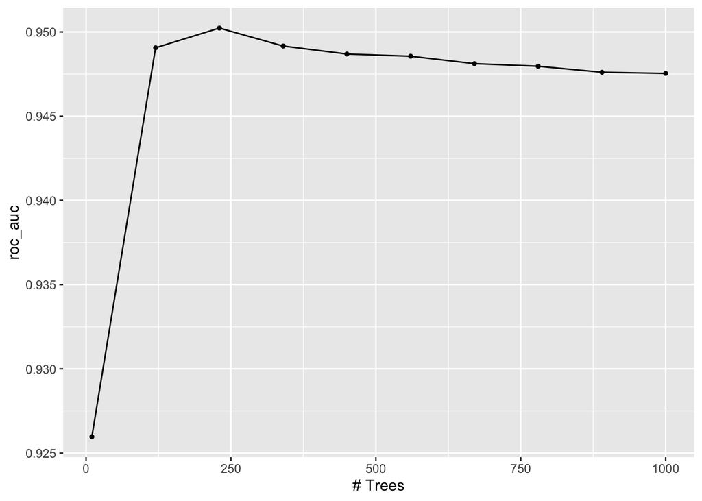

```r
autoplot(tune_boost_res)
```

```r
boost_metrics <- collect_metrics(tune_boost_res) %>% dplyr::arrange(-mean)

df <- data.frame(Metric = boost_metrics$.metric, Value = boost_metrics$mean, Standard_Error = boost_metrics$std_err, trees_Value = boost_metrics$trees )

kable(head(df))
```

| Metric | Value | Standard_Error | trees_Value |
| --- | --- | --- | --- |
| roc_auc | 0.9502284 | 0.0015047 | 230 |
| roc_auc | 0.9491613 | 0.0014320 | 340 |
| roc_auc | 0.9490592 | 0.0013709 | 120 |
| roc_auc | 0.9486886 | 0.0013957 | 450 |
| roc_auc | 0.9485587 | 0.0013975 | 560 |
| roc_auc | 0.9481170 | 0.0014065 | 670 |

```r
best_boost_roc_auc <- df[1,2]
boost_se <- df[1,3]
```

Using the boosted tree model we see that the best ROC_AUC is 0.9502284 with Standard Error of 0.0015047 and 230 trees. The boosted model did better than the simple tree model and logistic regression. I think it did better because it is gradient boosted and like the simple tree model it also resamples the model in each tree.

## Model selection

After doing Tuned Hyperparameters for Logistic Regression, Tuned Hyperparameters for Tree Classification Model and Tuned Hyperparameters for Boosted Tree Model. We now proceed choose which model out of the 3 is the best. I will validate the model the best by their ROC_AUC

```r
Models<-c("Logistic Regression","Simple Tree Model","Boosted Tree Model")
roc_auc<-c(best_lr_roc_auc,best_tree_roc_auc,best_boost_roc_auc)
se<-c(lr_se,tree_se,boost_se)

df<-data.frame(Models=Models,ROC_AUC=roc_auc,Standard_Error =se)
df<-df %>% arrange(-roc_auc)
kable(df)
```

| Models | ROC_AUC | Standard_Error |
| --- | --- | --- |
| Boosted Tree Model | 0.9502284 | 0.0015047 |
| Simple Tree Model | 0.8887092 | 0.0042210 |
| Logistic Regression | 0.8727775 | 0.0031711 |

As we can see from the table, Boosted Tree classifciation model did the best for this dataset as it has an ROC_AUC of 0.9502284 which is the highest and very close to 1. Not only that, this model also has the lowest standard error from the other 2 models.

This is the hyper parameters that were tuned for the best Boosted Tree Clasification Model

```r
best_vals<-select_best(tune_boost_res)
kable(best_vals)
```

| trees | .config |
| --- | --- |
| 230 | Preprocessor1_Model03 |

With 230 Trees, the Boosted Tree Model is able to produce 0.9502284 ROC_AUC. Next we proceed with this model to be fitted to the test data.

## Fitting to test data and see performance

### ROC Curves

```r
require(knitr)
boost_final<-finalize_workflow(boost_wf,best_vals)
boost_final_fit<-fit(boost_final,data = data_train)
boost_final_res<-augment(boost_final_fit, new_data = data_test)
boost_final_res_1<- augment(boost_final_fit, new_data = data_test) %>% roc_auc(loan_status,estimate= .pred_1)
boost_final_res_0<- augment(boost_final_fit, new_data = data_test) %>% roc_auc(loan_status,estimate= .pred_0)

ROC_AUC=c(boost_final_res_0$.estimate,boost_final_res_1$.estimate)
Cateogry= c('0 (Non-Default)', '1 (Default)')
df<-data.frame(ROC_AUC,Cateogry)
kable(df)
```

| ROC_AUC | Cateogry |
| --- | --- |
| 0.9496109 | 0 (Non-Default) |
| 0.0503891 | 1 (Default) |

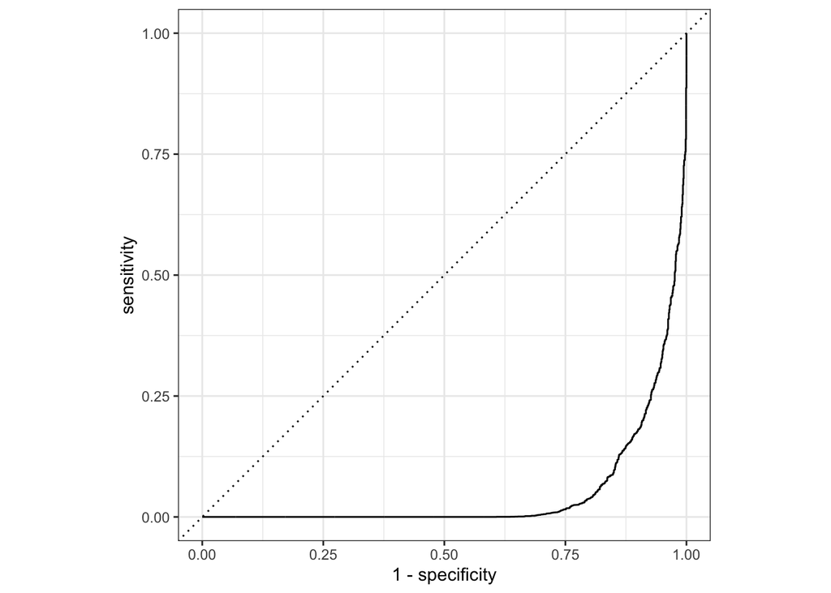

```r
par(mfrow=c(1,2))
autoplot(augment(boost_final_fit, new_data = data_test) %>% roc_curve(loan_status, estimate=.pred_1))
```

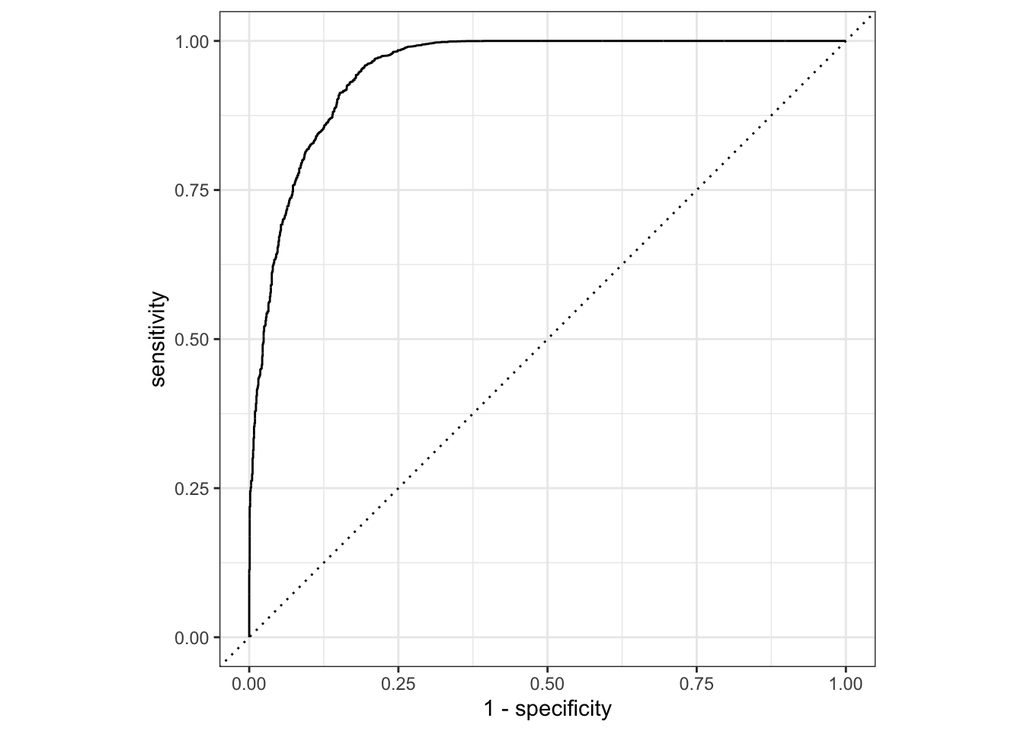

```r
autoplot(augment(boost_final_fit, new_data = data_test) %>% roc_curve(loan_status, estimate=.pred_0))
```

### Confusion Matrix

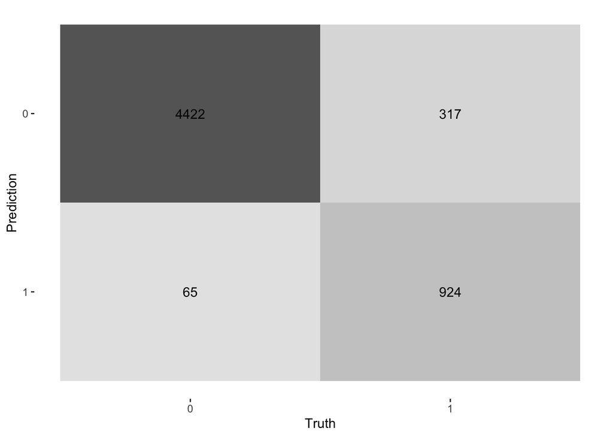

```r
#Confusion Matrix
augment(boost_final_fit, new_data = data_test) %>%
  conf_mat(loan_status, estimate = .pred_class) %>%
  autoplot(type = 'heatmap')
```

```r
#accuracy, sensitivity, specificity
multi_metric <- metric_set(accuracy, sensitivity, specificity)
augment(boost_final_fit, new_data = data_test) %>%
  multi_metric(truth = loan_status, estimate = .pred_class) %>% kable()
```

| .metric | .estimator | .estimate |
| --- | --- | --- |
| accuracy | binary | 0.9333101 |
| sensitivity | binary | 0.9855137 |
| specificity | binary | 0.7445608 |

After fitting the Boosted Tree Classification Model, I see that the result that is predicted for the model towards the testing data is pretty outstanding. From the confusion matrix itself, I saw that my data predict most of the observations true. As you can see too, I obtain an accuracy of 93%, sensitivity of 98.5% and specificity of 74.4%. I think the reason behind why more of the response “0 (Non-Default)” are predicted truly more than the response “1 (Default)” is that because our data response variable consist mostly of the response “0 (Non-Default)” . If you think about it, it makes sense because a bank that has high defaults will most likely fail.

### Variable Importance Plot

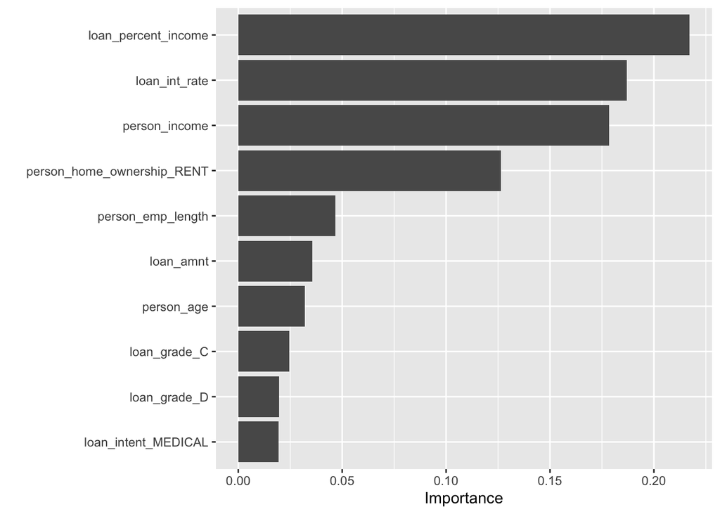

```r
vip(boost_final_fit%>% extract_fit_parsnip())
```

From Looking at the Variable Importance Plot, I do agree loan_percent_income being the most important variable to predict loan status. The more your loan to income ratio, the more you are post a risk towards the bank.

## Conclusion

This project was fun and educative for me. I tried to implement the stuff I learn in PSTAT 131 in a real world problem. Although the result is not what I wanted, I cannot say that I did everything wrongly. Maybe if I change the order factor of my response variable then this would produce a different outcome.

To conclude this project, the best model I got is a Boosted Tree Classification Model with 230 trees tuned.

## References

Dataset: https://www.kaggle.com/datasets/laotse/credit-risk-dataset Homeworks Labs Lecture Slides